# Codex First Contact

Lecture 12b  
POLS 6394 · Thursday, November 12

## Today

- Discuss Mollick’s reading: where would uneven capabilities matter in your work?
- Open Codex and check its settings and remaining allowance.
- Read files, fix one line, then create a cleaning script.
- Check the changes with `/diff` and RStudio’s Git pane.
- Watch delegation, then plan, check, and commit one scoped change.

# After Posit Assistant

## The reading: jagged capabilities

*~8 minutes together.*

Mollick calls the model’s capabilities “jagged”: strong results on some tasks can sit beside important weaknesses.

In your own research:

- What would you let an agent attempt?
- Where would you hesitate to trust its judgement?
- What could you check independently?

Ethan Mollick, [“Fable 5.2 and Jagged AGI”](https://www.oneusefulthing.org/p/fable-52-and-jagged-agi), November 9, 2026.

## Two ways to work with an agent

|  | Posit Assistant | Codex in the terminal |
| --- | --- | --- |
| Starting point | RStudio, with your session | A folder of files |
| Context | Files and tools for inspecting R | Files and command output |
| Useful example | Plot an object already in R | Change a script and inspect its diff |
| Your check | Run and inspect the result | Run and inspect the result |

Both can act on files. The **harness** is the software that gives the model its tools and permissions.

## Today’s folder

`Labs/w12/sandbox` is already inside your coursework repository.

- Synthetic teaching data for 12 states.
- One deliberately misspelled column name.
- A place to practice on files you can inspect yourself.

We’ll use that existing folder. If you’ve already worked in it, keep your changes and tell us.

# Getting there

## Start every terminal with `course`

Open **Ghostty** on a Mac or **Git Bash in Windows Terminal** on Windows. Type:

```bash
course
```

Wherever the terminal opens, **`course` takes you to your course repository**. It’s the shortcut you set up in 11a. Make it the first thing you type, every time.

If `course` isn’t found, open RStudio at your course project and choose **More → Open New Terminal Here** in the Files pane.

## Where you are

```bash
pwd
ls -l
```

`pwd` prints the folder you’re in: it should end in your course repository’s name. `ls` lists what’s in it; `-l` adds details. A line starting with `d` is a folder.

## Turn on the terminal helpers

From the course repository:

```bash
bash Setup/terminal-setup.sh
```

`bash` runs the supplied script. It backs up your shell settings, then turns on two helpers we’ll use next: `z` and Ctrl-R.

Close the terminal and open a new one. Type `course` again. Then `type z` should say that `z` is a function; `type` tells you what a command name refers to.

## Jump with `z`

```bash
z Labs/w12/sandbox
ls -l
course
z sandbox
pwd
```

- `z Labs/w12/sandbox` goes to that folder and remembers it. Slashes separate folders; Tab completes names.
- `course` takes you back to the top.
- `z sandbox` jumps back with just the folder’s name. `pwd` shows where you landed.

If `z` isn’t working (`type z` says not found, or `z sandbox` says no match), use `cd Labs/w12/sandbox` instead. `cd` changes folder the same way, without remembering.

## Find a command again: Ctrl-R

Press **Ctrl-R** (Control, not Command, on a Mac too). A list of commands you’ve typed before appears; that’s mcfly.

- Type part of a command, like `sandbox`, to narrow the list.
- Arrow keys move through it.
- **Enter** runs the highlighted command; **Tab** puts it on the command line so you can edit it first.
- **Esc** closes the list without running anything.

The Up arrow still steps back one command at a time.

## A checkpoint before the agent

Commit your earlier work in RStudio’s Git pane first, so anything Codex changes is easy to see.

- Keep existing notes and answers.
- If `R/clean.R` already exists, inspect it rather than overwrite it.
- Don’t copy a new sandbox or initialize another Git repository.

# Opening Codex

## Update Codex first

Codex changes often. Before starting it, at the shell prompt:

```bash
codex update
codex --version
```

- `codex update` downloads and installs the newest Codex. It can take a minute.
- `codex --version` prints the version you now have. Today’s slides were checked with 0.167.1.

## Start Codex

In the sandbox (`z sandbox`, then `pwd` to check):

```bash
codex
```

The first time, choose **Sign in with ChatGPT** and use the account with your subscription.

Codex then asks **Trust this folder?** and names your course repository, not the sandbox. It’s your own repository: say **yes**. It only asks once.

On Windows, it may also ask to set up a sandbox: choose the **default** and approve the administrator prompt. If your computer won’t allow that, choose **non-admin**.

Codex uses your ChatGPT subscription, not the API credit Posit Assistant uses.

## Choose the model first

Before asking Codex anything, inside Codex:

1. Type `/model` and press Enter.
2. Choose **GPT-6.1 Terra**.
3. When it asks how hard to think, choose **Medium**.

Terra at Medium is what we’ll use all semester: strong enough for this work without burning through your allowance.

## Permissions: Ask for approval

Codex starts in **Ask for approval**. It can read and edit files in this folder, and it asks before doing anything outside it. Keep that setting all class.

You decide where to pause it: ask for a plan before a bigger change, and read a commit before it runs.

If you can’t scroll back to earlier output, type `/exit` and start it again with `codex --no-alt-screen`.

## Your Turn: `/status`

*~2 minutes, included in setup.*

Inside Codex, type `/status` and press Enter.

Find:

- **Model, folder, permissions.** The model should say GPT-6.1 Terra, medium; the folder should end in `Labs/w12/sandbox`; permissions should say Ask for approval. If they don’t, type `/permissions` and choose it.
- **Five-hour limit.** How much is left, and when does it reset?
- **Weekly limit.** How much is left, and when does it reset? Labels may vary.

The percentages describe allowances, not API dollars. Keep your account details out of the workbook.

If anything looks different from what we expect, raise your hand.

## Instructions Codex reads every time

Your repository now has an `AGENTS.md` file in its top folder. Codex reads it at the start of every conversation anywhere in the repository; Posit Assistant reads it too.

Open it in RStudio. Some of what it says:

```markdown
- Use R. Follow tidyverse style: the base pipe `|>`, snake_case names,
  and readr to read and write files.
- Never change raw data. Write cleaned data to a new file.
- Don't commit or push unless I ask.
```

It’s yours: when you notice you keep telling the agent the same thing, add it here. It guides the agent; it doesn’t lock anything. Permissions still set what Codex can do.

## One file that points to others

Codex reads only `AGENTS.md` by itself. Yours tells it when to read three more, next to it in the top folder:

- `PAPER.md`: your paper project: question, data, where things are, how to render it.
- `CV.md` and `WEBSITE.md`: your CV and website, which live in their own projects.

They’re templates to fill in as your projects take shape. We start on `PAPER.md` next week.

Codex can edit any of them for you:

```
Add to AGENTS.md: my survey data are in Paper/Data/raw.
```

Then read the change with `/diff`, as with any other edit.

# Guided practice

## Three steps

| Step | What you permit | What you check |
| --- | --- | --- |
| 1 | Explain named files | Files, columns, row unit |
| 2 | Edit one existing line | Diff and regional means |
| 3 | Create one script | Code and cleaned output |

The workbook stays at the coursework root. Codex works in `Labs/w12/sandbox`; the workbook chunks handle the paths.

## The data we’ll check

Run the workbook’s setup:

```r
library(tidyverse)
sandbox <- "Labs/w12/sandbox"
raw <- read_csv(file.path(sandbox, "data/turnout.csv"),
                show_col_types = FALSE)
```

These are synthetic teaching data. Each row is one state in the fixture, with a 2020 label; don’t treat the values as sourced election statistics.

## Ten sampled rows

```r
set.seed(6394)
raw |> slice_sample(n = 10)
```

```
# A tibble: 10 × 5
   state          region     year turnout registered
   <chr>          <chr>     <dbl> <chr>   <chr>
 1 Ohio           Midwest    2020 67.4%   8082901
 2 Georgia        South      2020 67.7%   N/A
 3 Texas          South      2020 60.4%   16955519
 4 New York       Northeast  2020 63.1%   12684272
 5 Washington     West       2020 75.7%   N/A
 6 Florida        South      2020 71.7%   14443954
 7 Pennsylvania   Northeast  2020 70.9%   9090422
 8 california     West       2020 68.5%   22047448
 9 North Carolina South      2020 71.5%   7361219
10 Illinois       Midwest    2020 <NA>    8264135
```

`turnout` is text such as `"60.4%"`. Our numeric version will be `0.604`.

State names need cleaning, and some values are missing.

## Step 1: explain without changes

Paste the workbook’s first prompt into Codex:

```
Read the files in this folder and tell me what each one does.
Don't change anything.
```

Read the explanation against the files, not just for whether it sounds plausible.

## Step 1: your independent check

```r
nrow(raw)
```

```
[1] 12
```

```r
names(raw)
```

```
[1] "state"      "region"     "year"       "turnout"    "registered"
```

```r
class(raw$turnout)
```

```
[1] "character"
```

```r
sum(is.na(raw$turnout))
```

```
[1] 1
```

```r
sum(raw$registered == "N/A", na.rm = TRUE)
```

```
[1] 2
```

Expect 12 rows, five columns, character turnout, one missing turnout and two `"N/A"` registrations.

## Your Turn: redirect, then stop

*~3 minutes.*

1. Paste:

```
Walk me through R/01-load.R, line by line.
```

2. While it’s answering, type this and press Enter:

```
Shorter: one sentence for the whole file.
```

3. Then paste the next one, and press **Esc** as soon as it starts:

```
Now explain every line of R/02-summary.R in detail.
```

## What you just did

- **Redirect:** type while Codex works and press Enter. It adjusts, but it still remembers what you asked before. To replace that, say so: “Drop that. Instead, …”
- **Stop:** **Esc** stops the current turn. The conversation stays; files it already changed stay changed.
- **Start fresh:** `/new` begins a conversation without the earlier requests. You’ll rarely need it: one long conversation is usually fine.

## Step 2: read the error

In the workbook:

```r
withr::with_dir(sandbox, source("R/02-summary.R", echo = TRUE))
```

```
> library(tidyverse)

> turnout <- mutate(read_csv("data/turnout.csv", show_col_types = FALSE),
+     turnout = parse_number(turnout)/100)

> arrange(summarise(group_by(turnout, regon), mean_turnout = mean(turnout,
+     na.rm = TRUE)), desc(mean_turnout))
```

```
Error in `group_by()`:
! Must group by variables found in `.data`.
✖ Column `regon` is not found.
```

`withr::with_dir()` temporarily enters the sandbox. `source()` runs the script; `echo = TRUE` prints code and results. R then returns to the project root.

The supplied script fails at `group_by(regon)`. If yours is already fixed, leave it fixed.

## Step 2: the one-line job

```
theres a typo in 02-summery.R that breaks it. fix just that line
and tell me what was wrong. dont run it
```

The typos are on purpose. Watch whether it finds the right file despite the spelling; models usually read past mistakes like these. Check the diff before assuming it did.

**The job:** fix the typo. **The fence:** just that line; don’t run it.

Leave Codex open and read the change on the next slide.

## Reading that diff

In Codex, type `/diff` and press Enter. It shows what changed in your repository since your last commit, in its own full-window view. Arrow keys or PageDown scroll; press `q` to close it and return to Codex.

A schematic diff:

```
-  group_by(regon) |>
+  group_by(region) |>
```

`-` marks a removed line; `+` marks an added line. Check that this is the only change: `regon` became `region`.

## Step 2: run and compare

Rerun the script in RStudio, then compare with:

```r
raw |>
  mutate(turnout = parse_number(turnout) / 100) |>
  group_by(region) |>
  summarize(mean_turnout = mean(turnout, na.rm = TRUE)) |>
  arrange(desc(mean_turnout))
```

```
# A tibble: 4 × 2
  region    mean_turnout
  <chr>            <dbl>
1 Midwest          0.707
2 West             0.700
3 South            0.678
4 Northeast        0.67
```

Midwest `0.7065`; West about `0.7003`; South `0.67825`; Northeast `0.67`.

The raw CSV still contains text percentages. This script already divides by 100.

## Step 3: create one script

In the same Codex session, paste:

```
Write R/clean.R to clean data/turnout.csv and save the result as
data/turnout_clean.csv. Turnout should be a fraction, N/A means
missing, and the state names need tidying. Keep every row. Just
write the script; I'll run it. If clean.R already exists, ask me first.
```

No row count or Texas value in the prompt: you keep those to check against.

Then type `/diff` to see the new file: it shows new files in full. They also appear in RStudio’s Git pane with a yellow `?`.

Open `R/clean.R` in RStudio and read it before running it.

## Step 3: run your cleaner

Run this chunk in the root workbook after reading the script. Don’t use Source on `clean.R` itself: its relative paths need the sandbox as the working folder.

```r
# Delete the eval:false line after you have read R/clean.R.
withr::with_dir(sandbox, source("R/clean.R"))
```

That run writes the CSV. Codex was asked to create only the R script.

Then enable the output checks.

## Step 3: inspect the written file

```r
# Delete the eval:false line once turnout_clean.csv exists.
clean <- read_csv(file.path(sandbox, "data/turnout_clean.csv"),
                  show_col_types = FALSE)
glimpse(clean)
nrow(clean)
sum(is.na(clean$turnout))
sum(is.na(clean$registered))
clean |> filter(state %in% c("Texas", "California", "Illinois"))
```

Expect 12 rows; one missing turnout; two missing registrations; Texas `0.604` and capitalized `California`.

# Delegation

## One agent supervises two helpers

*~4 minutes; watch the instructor.*

A **subagent** is another agent given a smaller job. Here:

- One checks the cleaner’s file paths and column names.
- One checks Texas’s turnout against the raw data.
- The parent checks both findings against the evidence.

These are independent checks that change nothing. The parent still owns the answer.

The instructor compares the Git pane before and after.

[OpenAI: subagents](https://learn.chatgpt.com/docs/agent-configuration/subagents)

## A delegation prompt

```
Have two helper agents check R/clean.R without changing anything:
one checks the file paths and column names, the other checks Texas's
turnout. Use Luna for the helpers if you can. Then check their answers
yourself and tell me what they found and which models ran.
```

Available models and delegation controls vary. If they’re unavailable, we’ll show the checks sequentially.

Helpers do additional model work. More agents doesn’t automatically mean less usage.

## Let it ask you questions

You don’t have to work out every detail before you prompt. Sketch the idea in a sentence, then let Codex interview you:

```
I want average turnout by region, saved as a CSV, plus a plot.
Before you plan anything, ask me what you need to know, one
question at a time.
```

It asks and you answer. The rough idea becomes a full request, including the fence: which files, what stays the same, how you’ll check.

Then ask for a plan, read it, and approve.

## Lab: sketch, answer, plan

*~16 minutes, including the commit and verification below.*

1. Paste the sketch above.
2. Answer its questions. Good ones include: should every state count equally, or by registered voters? What about the missing values? Which files?
3. If it asks about names, use `R/region-summary.R`, `data/region_summary.csv` and `region_turnout.png`. Nothing existing should change.
4. Ask for the plan without edits. Read it, then approve.
5. Read the change with `/diff`, then run the check.

If it never asks about weighting, ask it yourself. That’s the decision that changes the answer.

## Lab: run the check

```r
# Delete the eval:false line after reading R/region-summary.R.
withr::with_dir(sandbox, source("R/region-summary.R"))
read_csv(file.path(sandbox, "data/region_summary.csv"),
         show_col_types = FALSE)
clean <- read_csv(file.path(sandbox, "data/turnout_clean.csv"),
                  show_col_types = FALSE)
clean |>
  group_by(region) |>
  summarize(equal = mean(turnout, na.rm = TRUE))
clean |>
  filter(!is.na(turnout), !is.na(registered)) |>
  group_by(region) |>
  summarize(weighted = weighted.mean(turnout, registered))
```

The first table is Codex’s; the next two are yours. Equal weight: Midwest 0.7065, West about 0.700, South 0.678, Northeast 0.67. Weighted by registered voters: West about 0.681, South 0.667. Which did Codex use, and is that what you asked for?

## Why the two answers differ

- **Weighting.** A weighted mean counts big states more. Texas has many voters and low turnout, so it pulls the South down.
- **Missing values.** Georgia and Washington have no registration count, so the weighted mean leaves them out. Washington has the West’s highest turnout; dropping it is most of why the West falls.
- Neither is wrong. The question is which one you meant, and whether the agent knew.

# Keeping the work

## Have Codex propose a commit

*Part of the 16-minute end lab. First write one check in `NOTES.md`, then save and render the workbook so the commit includes your latest version.*

```
Commit today's work: the summary fix, clean.R and its output, the
region summary script, table and plot, my notes, and the workbook at
../../../12b-workbook.qmd in the repository root.
Show me the exact commands first and wait. Don't push.
```

Read the paths and message. You should see the sandbox files `R/02-summary.R`, `R/clean.R`, `data/turnout_clean.csv`, `R/region-summary.R`, `data/region_summary.csv`, `region_turnout.png` and `NOTES.md`, plus the root `12b-workbook.qmd`, and nothing else. From the sandbox, `../../../12b-workbook.qmd` goes up three folders to reach it. `git add` stages the files it names; `git commit -m` records them with that message. Naming files keeps unrelated work out, so don’t accept a command that stages everything. If they match, tell Codex to run those commands. A Git write may need approval: read the exact command and approve once.

## Check the commit, then push

In RStudio:

1. Open the Git pane and click **History**. If the new commit isn’t there, refresh the pane.
2. Click the latest commit. Its files should be exactly the eight above.
3. Click **Push**.

If you write more in the workbook after this commit, save and commit it again in the Git pane before pushing. If Codex can’t commit, use the fallback next.

## If Codex can’t commit, or you want to undo

**Can’t commit:** commit those files in the Git pane as usual.

**Undo a change:** ask Codex to undo it and check `/diff`. Or select the file in the Git pane and choose **Revert**, which throws away that file’s uncommitted changes.

If Codex already made the correct commit, you don’t need either.

# Coming back later

## Your Turn: leave and come back

*~2 minutes.*

```bash
/exit
codex resume --last
```

- `/exit` closes Codex. Your conversation is saved.
- `codex resume --last`, typed at the shell, reopens the most recent conversation in this folder.

Scroll up: your earlier work is still there. Type `/status` and check the permissions; set `/permissions` again if they changed.

## Several conversations, one folder

Plain `codex resume`, from the same folder, lists your earlier conversations:

```bash
codex resume
```

`resume` lists your earlier conversations; choose one with the arrow keys and Enter. `codex resume --last` reopens the most recent one directly.

One folder can have several conversations, say one per task. `resume` lets you pick which to continue.

Files don’t depend on the conversation: whatever Codex changed is already on disk.

## When a conversation gets long

Everything in a conversation takes up room in the model’s working memory, its **context**.

When that fills, Codex **compacts**: it summarizes the older parts and keeps going. Most of the time you won’t notice, and you don’t need to do anything.

If it seems to have lost a detail, say it again. Anything that must never be lost belongs in a file, like `AGENTS.md` or `NOTES.md`.

`/compact` does it on request; you’ll rarely need that either.

## When the laptop sleeps, Codex stops

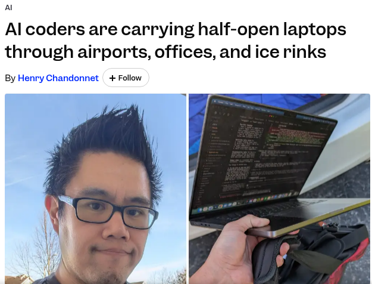

Codex runs on your computer. When it sleeps or shuts down, Codex can’t keep working.

For jobs of seconds or minutes, that doesn’t matter.

For longer ones, plan for it:

- Keep the laptop awake and plugged in.
- Or run the agent on a computer that stays on: a desktop at home or work, or a server.

After sleep or a dropped connection, check what finished before asking Codex to continue.

Henry Chandonnet, [“AI coders are carrying half-open laptops through airports, offices, and ice rinks,”](https://www.businessinsider.com/coders-keep-laptops-open-in-public-ai-agent-2026-5) *Business Insider*, May 12, 2026.

## Switching computers

**Files travel with Git.** Push on one computer, pull on the other, and your project is there.

**Conversations don’t.** Codex saves them in a hidden folder (`~/.codex`) on the computer where they happened. On another machine, `codex resume` won’t find them, and the agent starts with no memory of the work.

Dropbox or Google Drive doesn’t fix this. Syncing that folder between computers is fragile.

So for now, **start and finish a task on one computer.** Put what you want to keep, like plans, checks and decisions, in files such as `NOTES.md` or `AGENTS.md`. Those travel with Git.

I got conversations working across my own computers with some crazy hacking, but it was brittle. The fix I eventually learned: run one machine that stays on, and connect to it from every other computer.

## Before Next Class

- Render the workbook, check the changes in the Git pane, then commit and push.
- Keep your check notes even if Codex made no mistakes.
- Finish incomplete guided work by 7 PM the night before our next class. Check the course announcements for the next meeting time.
- **Pset 6: Tuesday, November 17, 7 PM Central.**

# If Time Remains

## Extension 1: instructions that persist

*~10 minutes.*

A folder can have its own `AGENTS.md` too. Codex reads the top-level file and then the folder’s, so the folder’s rules add to the general ones.

Create a file named `AGENTS.md` in this practice folder, next to `README.md`:

```markdown
# Turnout practice

Use tidyverse and the base pipe.
Keep raw data/turnout.csv unchanged.
Store turnout as a fraction between 0 and 1.
Ask before installing packages or changing other folders.
```

Add one checking instruction. If a file already exists, read it first.

## Extension 1: a fresh chat

Start a new conversation with `/new`. Ask it to identify the project instructions and explain how it would check `R/clean.R`.

Compare the answer with your file.

Guidance can persist without you repasting it. It doesn’t guarantee compliance or replace permission controls.

## Extension 2: a supplied claim

*~10 minutes. This is a made-up example, not a recorded run.*

Suppose the only permitted edit was `R/02-summary.R`:

```
Agent summary: Fixed the region name. Illinois turnout is 0.
Files changed:
 R/02-summary.R (edited)
 R/extra-check.R (new)
No execution output is shown.
```

What can you establish? What still needs evidence?

## Extension 2: check the number

```r
raw |>
  mutate(turnout = parse_number(turnout) / 100) |>
  filter(str_to_title(str_trim(state)) == "Illinois") |>
  select(state, turnout)
```

```
# A tibble: 1 × 2
  state    turnout
  <chr>      <dbl>
1 Illinois      NA
```

Illinois turnout is missing (`NA`), not zero. Read any new file before deciding what it does.

A file path outside the authorized edit needs investigation. A claim of execution needs evidence that it ran.

## When two helpers help

*Optional delegation practice, ~8 minutes for the next four slides.*

Delegate jobs that are **independent, bounded, and checkable**:

- One helper checks the cleaner’s paths and column names.
- Another checks Texas’s turnout conversion.
- The parent compares their evidence with the files and the known answer.

Don’t give two helpers edits to the same file. If job B needs job A’s output, do A first.

## A prompt isn’t a permission setting

“Don’t change anything” in a prompt tells the model what you want. It doesn’t change Codex’s permissions.

Helpers inherit the parent’s permissions, so they can edit too. That’s why you check.

Afterward, look at RStudio’s Git pane. Compare with how it looked before: the checking task should add no file changes.

[OpenAI: subagents and permissions](https://learn.chatgpt.com/docs/agent-configuration/subagents)

## Your Turn: supervise the helpers

Use the two-helper prompt from the demonstration in your own session. Your working files should stay unchanged.

Read each helper’s report and the parent’s summary:

1. Which file or value supports each finding?
2. Did the parent check it, or just repeat it?
3. Does the Texas conversion agree with `0.604`?

If delegation isn’t available, ask for the same two checks sequentially. You can still evaluate the evidence.

## Check the allowance, too

Run `/status` before and after the helper exercise. Compare the five-hour and weekly percentages.

They may not visibly move after one small task. A rounded percentage isn’t a token bill or a price per helper.

Helpers do additional model work. Delegation can speed independent work; it isn’t automatically cheaper. Don’t record your account details in the workbook.

## Ask Codex to write checks

*Optional checks exercise, ~10 minutes for the next five slides.*

```
Write R/check-clean.R with a function check_clean() that stops with
an error if a cleaned table looks wrong. It should have 12 rows, one
missing turnout, two missing registrations, and Texas at 0.604.
Don't run anything.
```

Read the new file before running it. These are requirements you supplied, not evidence the script meets them.

## Read an assertion

An **assertion** is a condition that must hold. `stopifnot()` stops with an error if a condition isn’t true.

Example only; inspect the corresponding line in the generated function:

```r
stopifnot(nrow(x) == 12)
```

`x` is the table passed to `check_clean()`. `nrow(x)` counts its rows; `== 12` tests that count. A failed assertion identifies a broken expectation, not necessarily its cause.

## Run the checks yourself

Run this chunk in the root workbook. `withr::with_dir()` temporarily enters the sandbox to source the checker, and `file.path()` finds its saved CSV from the project root. Don’t Source the R script directly from the editor.

```r
# Delete the eval:false line once R/check-clean.R exists.
withr::with_dir(sandbox, source("R/check-clean.R"))
clean <- read_csv(file.path(sandbox, "data/turnout_clean.csv"),
                  show_col_types = FALSE)
check_clean(clean)
```

The first line defines the function. The next lines read the written file and pass it to that function. No error means these checks passed—not that every possible error was ruled out.

## Does a check notice a wrong value?

Create a temporary **R object**, not a changed CSV:

```r
bad <- clean
bad$turnout[is.na(bad$turnout)] <- 0
check_clean(bad)
```

`bad` starts as a copy. The second line replaces its missing turnout with zero. Expect the assertion about one missing turnout to fail.

The raw CSV, cleaned CSV, and cleaner stay unchanged. An error is the intended result of this probe.

## Read the failure, not just the verdict

Which expectation failed? Does that match the one value you deliberately changed?

Then run `check_clean(clean)` again. It should still pass.

If both versions pass, inspect the assertions. If both fail, inspect the data and the check. Ask Codex to explain the discrepancy without editing anything first.

Keep your hand check of Texas. An agent can write a mistaken test as well as mistaken cleaning code.

## A second opinion isn’t a test

`/review` asks Codex to review code changes. `/diff` shows the changes themselves; new files also appear in RStudio’s Git pane.

Ask for a review only of files you’ve inspected. Read the review against the actual `/diff` and your R checks.

A useful finding names a file, a problem, and its consequence. “Looks good” is not execution evidence. Review may also miss a problem.

[OpenAI: CLI commands](https://learn.chatgpt.com/docs/developer-commands?surface=cli)

## Continue tomorrow, or start fresh

`/new` starts a new conversation. It doesn’t undo file edits. From the shell, `codex resume` opens the session picker to continue an earlier conversation.

When resuming, check the folder and permissions again with `/status`, then check `/diff` and the Git pane: files may have changed since the last conversation.

[OpenAI: CLI commands](https://learn.chatgpt.com/docs/developer-commands?surface=cli)